# Data Visualization Project

## Flights Dataset

### By Alhanoof Alnajashi

Flight dataset describe all flights procces and delay in January - 2019.

Srource of the data [Here](https://www.transtats.bts.gov/DL_SelectFields.asp?Table_ID=) This dataset includes more data form January 2019.  
"It contains scheduled and actual departure and arrival times reported by certified U.S. air carriers that account for at least one percent of domestic scheduled passenger revenues. The data is collected by the Office of Airline Information, Bureau of Transportation Statistics (BTS)." [source](https://www.transtats.bts.gov/DatabaseInfo.asp?DB_ID=120&DB_URL=Subject_ID=2&Subject_Desc=Freight%20Transport&Mode_ID2=0)

#### Information about the data set:

There are 33 attributes which are:  
YEAR : which is 2019.  
QUARTER : quarter by the year in form (1-4).  
MONTH.  
DAY_OF_MONTH.  
DAY_OF_WEEK.  
FL_DATE : flight date.  
ORIGIN_AIRPORT_ID.  
ORIGIN_AIRPORT_SEQ_ID.  
ORIGIN_CITY_MARKET_ID.  
ORIGIN.  
ORIGIN_CITY_NAME.  
DEST_AIRPORT_ID.  
DEST_AIRPORT_SEQ_ID.  
DEST_CITY_MARKET_ID.  
DEST.  
DEST_CITY_NAME.  
DEP_TIME.  
DEP_DELAY.  
DEP_DELAY_NEW.  
TAXI_OUT.  
WHEELS_OFF.  
WHEELS_ON.  
TAXI_IN.  
ARR_TIME.  
ARR_DELAY.  
CANCELLED.  
DIVERTED.  
AIR_TIME.  
FLIGHTS.  
DISTANCE.  
CARRIER_DELAY.  
WEATHER_DELAY.

```python
# import all packages and set plots to be embedded inline
import numpy as np
import pandas as pd
import matplotlib.pyplot as plt
import seaborn as sb

%matplotlib inline
```

```python
#load data and overview
Flight = pd.read_csv('Flight.csv')
Flight.info()
```

```
<class 'pandas.core.frame.DataFrame'>
RangeIndex: 60941 entries, 0 to 60940
Data columns (total 33 columns):
 #   Column                 Non-Null Count  Dtype
---  ------                 --------------  -----
 0   YEAR                   60941 non-null  int64
 1   QUARTER                60941 non-null  int64
 2   MONTH                  60941 non-null  int64
 3   DAY_OF_MONTH           60941 non-null  int64
 4   DAY_OF_WEEK            60941 non-null  int64
 5   FL_DATE                60941 non-null  object
 6   ORIGIN_AIRPORT_ID      60941 non-null  int64
 7   ORIGIN_AIRPORT_SEQ_ID  60941 non-null  int64
 8   ORIGIN_CITY_MARKET_ID  60941 non-null  int64
 9   ORIGIN                 60941 non-null  object
```

[output cut: 25 more lines]

### Data wrangling.

```python
#get copy of the data
Flight_clean = Flight.copy()
```

> Drop year and month column since it is already all in January 2019.

```python
#drop unneed variables
Flight_clean.drop(['YEAR','MONTH'], axis=1 ,inplace=True)
```

> Change type of some variables like cancelled/diverted flights it has to be encoding 0 or 1 so boolean type is greater.

```python
#change datatype from float to boolean to get the encoding data
Flight_clean['CANCELLED'] =Flight_clean['CANCELLED'].astype('bool')
Flight_clean['DIVERTED'] =Flight_clean['DIVERTED'].astype('bool')
```

```python
Flight_clean.info()
```

```
<class 'pandas.core.frame.DataFrame'>
RangeIndex: 60941 entries, 0 to 60940
Data columns (total 31 columns):
 #   Column                 Non-Null Count  Dtype
---  ------                 --------------  -----
 0   QUARTER                60941 non-null  int64
 1   DAY_OF_MONTH           60941 non-null  int64
 2   DAY_OF_WEEK            60941 non-null  int64
 3   FL_DATE                60941 non-null  object
 4   ORIGIN_AIRPORT_ID      60941 non-null  int64
 5   ORIGIN_AIRPORT_SEQ_ID  60941 non-null  int64
 6   ORIGIN_CITY_MARKET_ID  60941 non-null  int64
 7   ORIGIN                 60941 non-null  object
 8   ORIGIN_CITY_NAME       60941 non-null  object
 9   DEST_AIRPORT_ID        60941 non-null  int64
```

[output cut: 23 more lines]

```python
Flight_clean['CANCELLED'].value_counts()
```

```
False    58593
True      2348
Name: CANCELLED, dtype: int64
```

```python
#save clean data as new csv file
Flight_clean.to_csv('Flight_clean.csv', index=True)
```

### What is the structure of your dataset?

There are 60,941 flights in the dataset with 33 features.  
some variable are enconding like cancelled/diverted when it 1 that indicates cancelled/diverted flights ocuurrs.(1 = Yes , 0 = NO)

### What is the main feature of interest in your dataset?

I'm interested in figuring out what the best feature to detect the delays in flights.

### What features in the dataset do you think will help support your investigation into your feature of interest?

I think that delays will have an effect on each trip in the flights: the delay in weather, carrier, departure, and in arrival. Also, the days in a week or in month and origin/destination city. and cancelled/diverted flights.

### Questions to be asked about the data set:

- What are the factors affecting delays?
- Which city has the highest arrival delay?
- What are the most days that have a delay?
- What are the days that have the highest flights?
- Which cities are the most began a destination city?
- What is the highest day in a month or in a week for flights?

## Univariate Exploration

Let's take over view in number of flights in a day?, what the distance between the airports?, and what are the top 3 destinations cities?.

##### First visualization.

Get some insight into the number of flights each day.

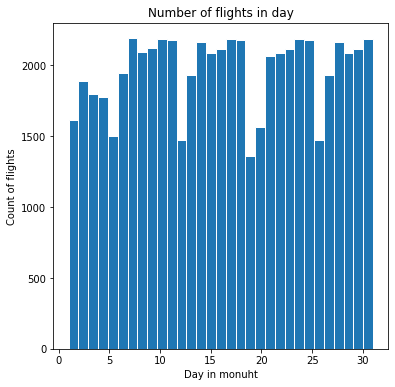

```python
#correlation between days and number of flights
plt.figure(figsize = (6,6))
plt.hist(data = Flight_clean, x = 'DAY_OF_MONTH' , bins = 31 , edgecolor = 'white')
plt.title('Number of flights in day')
plt.xlabel('Day in monuht')
plt.ylabel('Count of flights');
```

> This visualization showing the highest days in the month that are been chosen by the customers which are 7 and the days in the end of the month.

##### Second visualization.

By getting to know the highest number of flights in a day, let know where the destination of these flights.

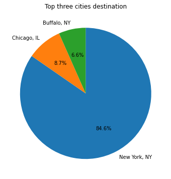

```python
#get the top 3 cities by taking a sub of the data [0:3]
plt.figure(figsize = (6,6))
sorted_counts = Flight_clean['DEST_CITY_NAME'].value_counts()[0:3]
plt.pie(sorted_counts, labels = sorted_counts.index, startangle = 90,autopct='%1.1f%%', counterclock = False)
plt.title('Top three cities destination');
```

> New York city gets almost 85% to a destination city in Jan-2019.

##### Third visualization.

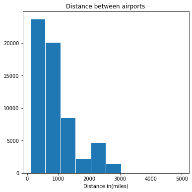

```python
#get the distance between airports
plt.figure(figsize = (6,6))
plt.hist(data = Flight_clean, x = 'DISTANCE' , edgecolor = 'white')
plt.title('Distance between airports')
plt.xlabel('Distance in(miles)');
```

> The last visualization in univariate exploration show distance between airports and almost the big freqency in distance 1000 miles and under.

### Discuss the distributions of your variables of interest. Were there any unusual points? Did you need to perform any transformations?

- I put a bins in first visualization by taking the days in month as bin to show the distrubtion cleary.
- The destinations cities are huge, do I just take the top 3 cities.

## Bivariate Exploration

After all these insights in univariate and since we need to know more let's combined more data in our insights and visualization. I want to look at the days correlations and some delays as well.

##### First visualization.

> Since we know the most days in the month that reserve by customers, let's discover the relation between the number of days in a week and in a month.

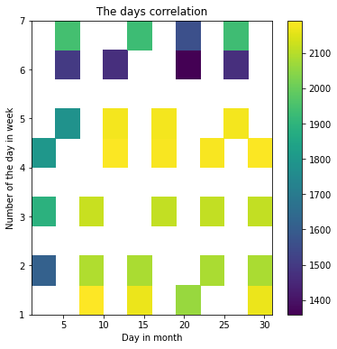

```python
#get frequncy between the day in week and day in month for flights.
plt.figure(figsize = (6,6))
plt.hist2d(data = Flight_clean , x='DAY_OF_MONTH' , y='DAY_OF_WEEK' , cmin=0.5)
plt.colorbar()
plt.xlabel('Day in month')
plt.ylabel('Number of the day in week')
plt.title('The days correlation');
```

> The fourth and fifth days in the week are most reserve, and from the middle of the month as well as that explains the number of flights we get it in univariate exploration.

##### Second visualization.

By getting to know the best days in a week for flights, let's discover some problems that may affect these flights, by getting to know the delays caused by the weather.

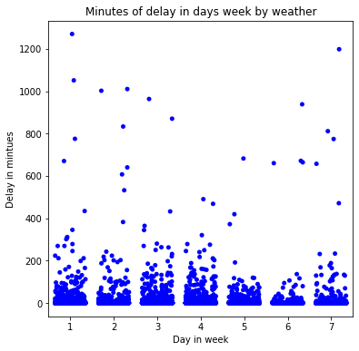

```python
#delay coused by weather
plt.figure(figsize = (6,6))
#jitter used to specify the overlapping that may happen and make the visualization more clear.
sb.stripplot(data = Flight_clean, x = 'DAY_OF_WEEK', y = 'WEATHER_DELAY' , jitter = 0.35 , color = 'blue')
plt.xlabel('Day in week')
plt.ylabel('Delay in mintues')
plt.title('Minutes of delay in days week by weather');
```

##### Third visualization.

Still, we need some information in destination cities to be more clear, here we get the top five cities destination and the origin cities, so we can get more insights.

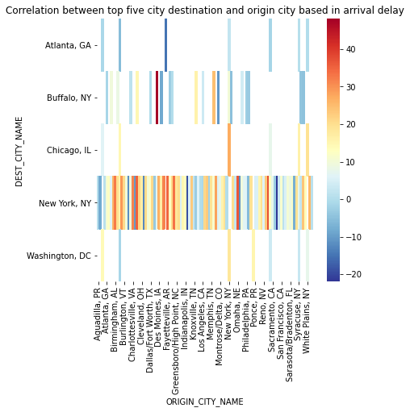

```python
#get the delays in arrival between the origin and destination city.
plt.figure(figsize = (6,6))
#Top 5 destination cities
top_cities = Flight_clean['DEST_CITY_NAME'].value_counts()[0:5].index
#Create dataframe for top 5 cities
top_cities = Flight_clean[Flight_clean.DEST_CITY_NAME.isin(top_cities)]
#Heat map
ct_counts = top_cities.groupby(['ORIGIN_CITY_NAME', 'DEST_CITY_NAME']).ARR_DELAY.mean()
ct_counts = ct_counts.reset_index(name='Arrival Delay')
ct_counts = ct_counts.pivot(index = 'DEST_CITY_NAME', columns = 'ORIGIN_CITY_NAME', values = 'Arrival Delay')
sb.heatmap(ct_counts , cmap = "RdYlBu_r")
plt.yticks(rotation = 0)
plt.title('Correlation between top five city destination and origin city based in arrival delay');
```

##### Fourth visualization.

after we know the correlation between cities in arrival delays, now we focus on arrival delays for these top cities in each day of the month, to get in which day the delays are getting higher.

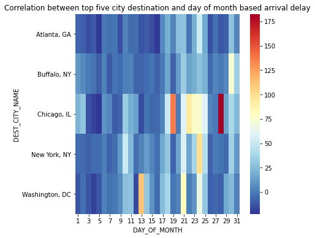

```python
#delay in arrival by top five city destination and day of month
plt.figure(figsize = (6,6))
ct_counts = top_cities.groupby(['DEST_CITY_NAME', 'DAY_OF_MONTH']).ARR_DELAY.mean()
ct_counts = ct_counts.reset_index(name='Arrival Delay')
ct_counts = ct_counts.pivot(index = 'DEST_CITY_NAME', columns = 'DAY_OF_MONTH', values = 'Arrival Delay')
sb.heatmap(ct_counts , cmap = "RdYlBu_r")
plt.yticks(rotation = 0)
plt.title('Correlation between top five city destination and day of month based arrival delay');
```

> Chicago has the highest delay in arrival on day 28 of the month, also on day 19.

## Multivariate Exploration

The main thing that wants to be explored here is how to get the correlation between the three types of delays and discover more in some other variables that may affect the analysis.

##### First visualization.

let the correlation in the delays does any of the delays will affect the other?

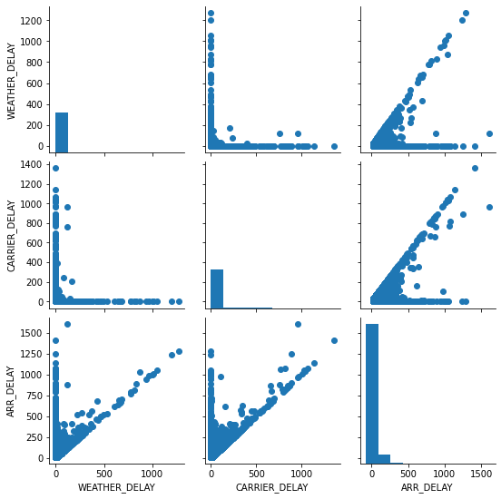

```python
#get the correlation between the weather , carrier , and arrival delays
plt.figure(figsize = (6,6))
g = sb.PairGrid(data = Flight_clean, vars = ['WEATHER_DELAY', 'CARRIER_DELAY', 'ARR_DELAY'])
g.map_diag(plt.hist);
g.map_offdiag(plt.scatter);
```

> I get here the main insights that any delays in weather or carrier delays will affect in the arrival time so it consider also as delays in arrivals and it gets increasing.

##### Second visualization.

After getting the correlation between the three types of delays, let get the correlation between the 2 types of delays with the distance between the airports does it really affect or not.

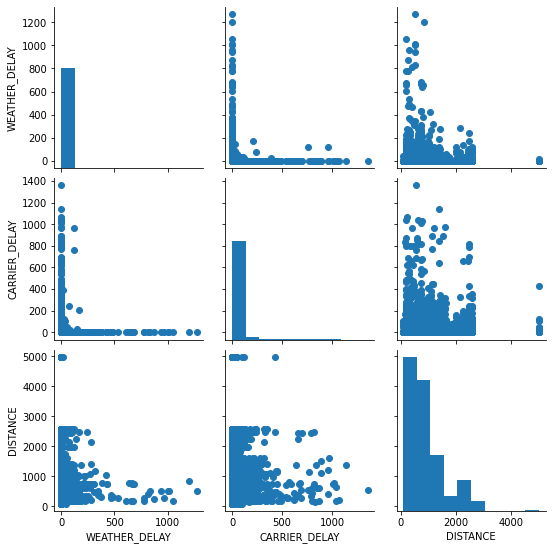

```python
#get the correlation between the weather/carrier delays and distance.
plt.figure(figsize = (6,6))
g = sb.PairGrid(data = Flight_clean, vars = ['WEATHER_DELAY', 'CARRIER_DELAY', 'DISTANCE'])
g.map_diag(plt.hist);
g.map_offdiag(plt.scatter);
```

##### Third visualization.

Let get the correlation between the origin and destination cities regarding the arrival delay.

[figure not shown]

```python
#correlation between cities and arrival delays.
plt.figure(figsize = (6,6))
g = sb.FacetGrid(data = Flight_clean, col = 'ORIGIN', height = 4,  col_wrap = 7)
g.map(plt.scatter, 'DEST', 'ARR_DELAY');
```

> This illustrates the arrival delay between the origin and destination cities, and we can get that JFK and LGA have the highest arrival delay.

> In the end, I think these insights may help the airline company and customer, by choosing the best day to make some offer to the customer or to avoid any day that has many delay flights.